# 2021.March

Alene Onion

3/9/2021

The goal of this recent iteration of our trend analysis is to assess the drivers of Chlorophyll A change using Kendall Tau slopes as well as Spearman Rank Coefficients in order to identify paramters to conduct AIC model confirmation.

## Parameters/Lakes

NOTE: summer TP and ChlA is the summer average calculated according to SOP 203: the average of the index period (July 15-Sept 15) is averaged with the average of samples collected in the summer (June-Sept) outside this index period.

## Seasonal KT

WARNING!!!! We suspect the trend in NO3/NO2 is actually a change in the method detection limit

Plot of all the seasonal KT values

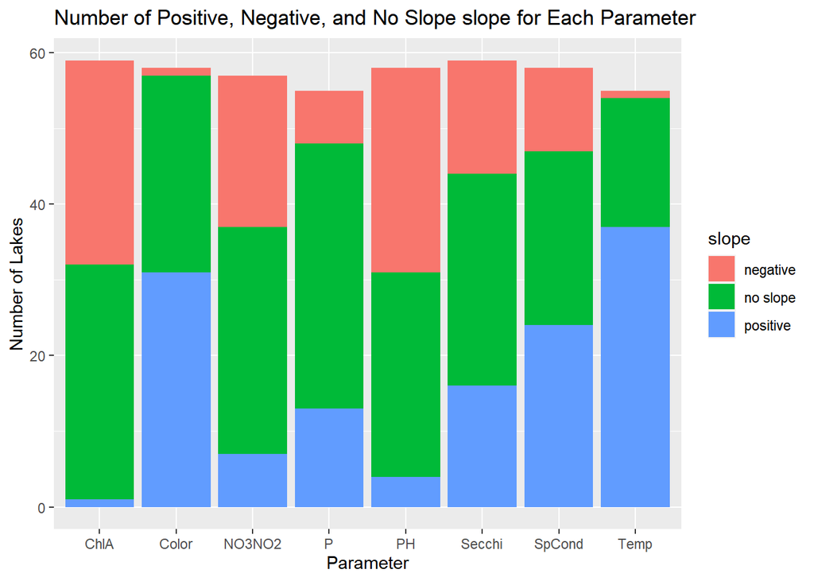

## Correlations ChlA

Correlations with parameters we measured

Correlations with parameters we didn’t measure

Table of correlation results. Black outlined boxes are statistically significant (p<0.05) and color indicates magnitude. Lakes below the black line have significant negative trends in ChlA

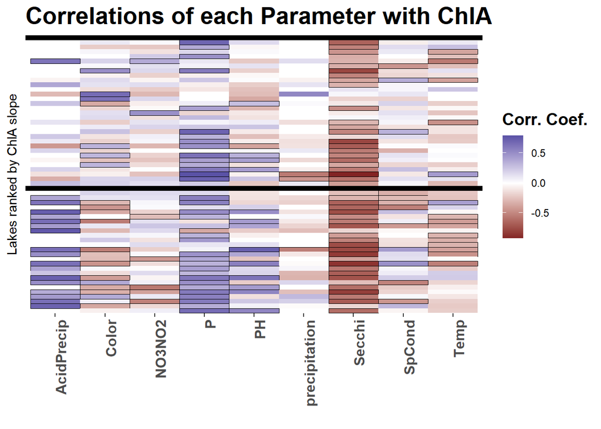

## Correlations Color

Correlations with parameters we measured

Correlations with parameters we didn’t measure

Table of correlation results. Black outlined boxes are statistically significant (p<0.05) and color indicates magnitude. Lakes below the black line have significant negative trends in Color

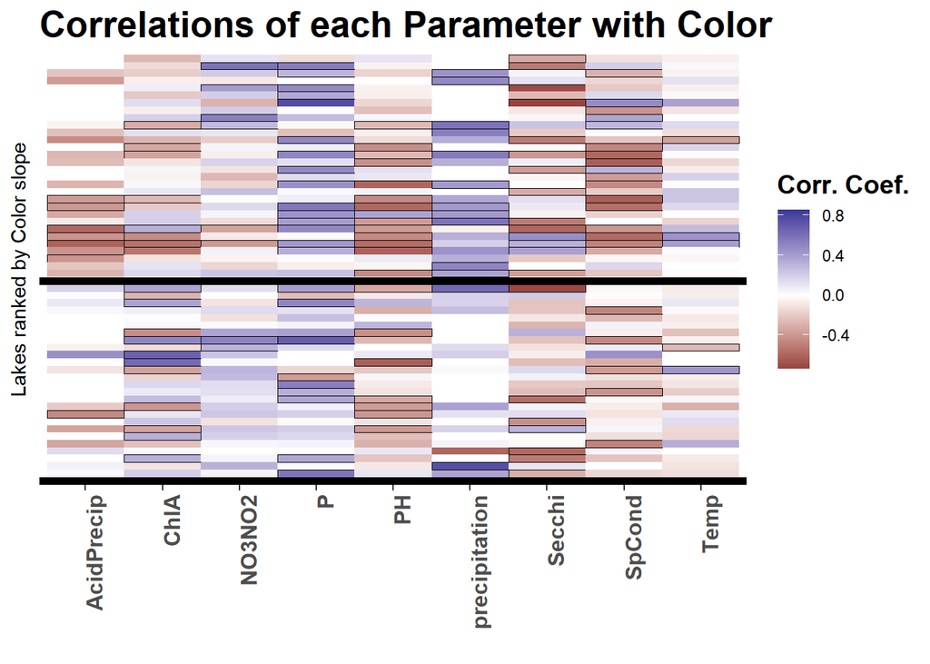

## Correlations P

Correlations with parameters we measured

Correlations with parameters we didn’t measure

Table of correlation results. Black outlined boxes are statistically significant (p<0.05) and color indicates magnitude. Lakes below the black line have significant negative trends in P

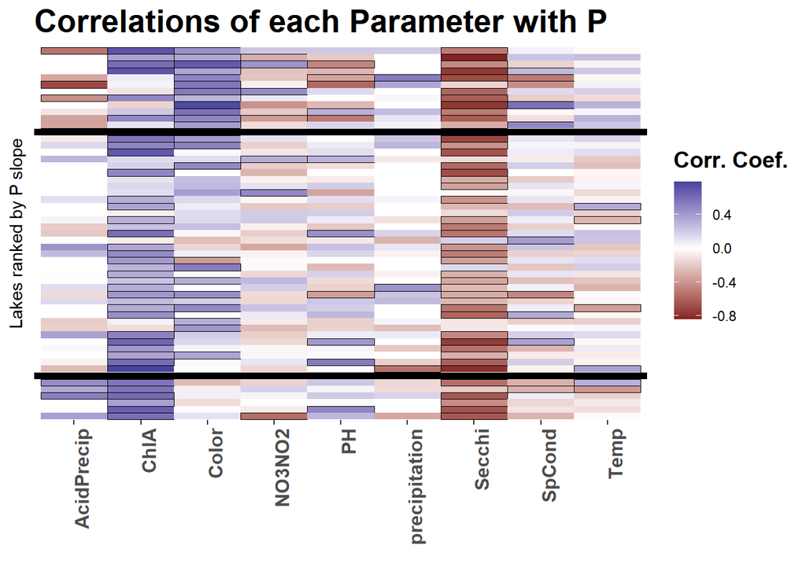

## Correlations PH

Correlations with parameters we measured

Correlations with parameters we didn’t measure

Table of correlation results. Black outlined boxes are statistically significant (p<0.05) and color indicates magnitude. Lakes below the black line have significant negative trends in PH

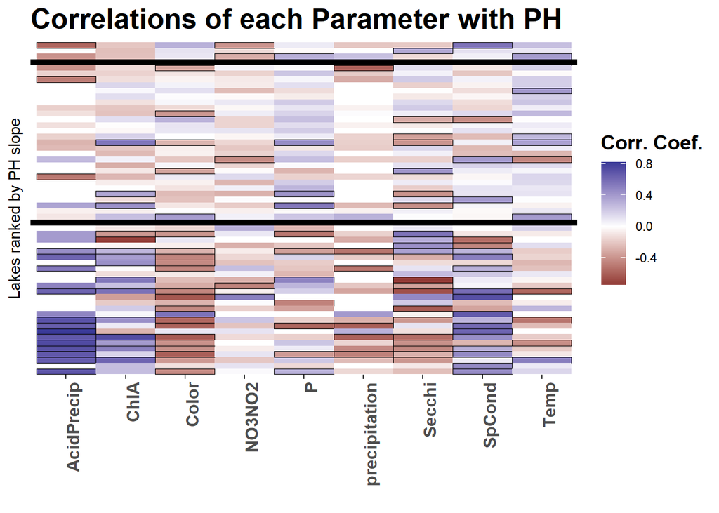

## Correlations Secchi

Correlations with parameters we measured

Correlations with parameters we didn’t measure

Table of correlation results. Black outlined boxes are statistically significant (p<0.05) and color indicates magnitude. Lakes below the black line have significant negative trends in Secchi

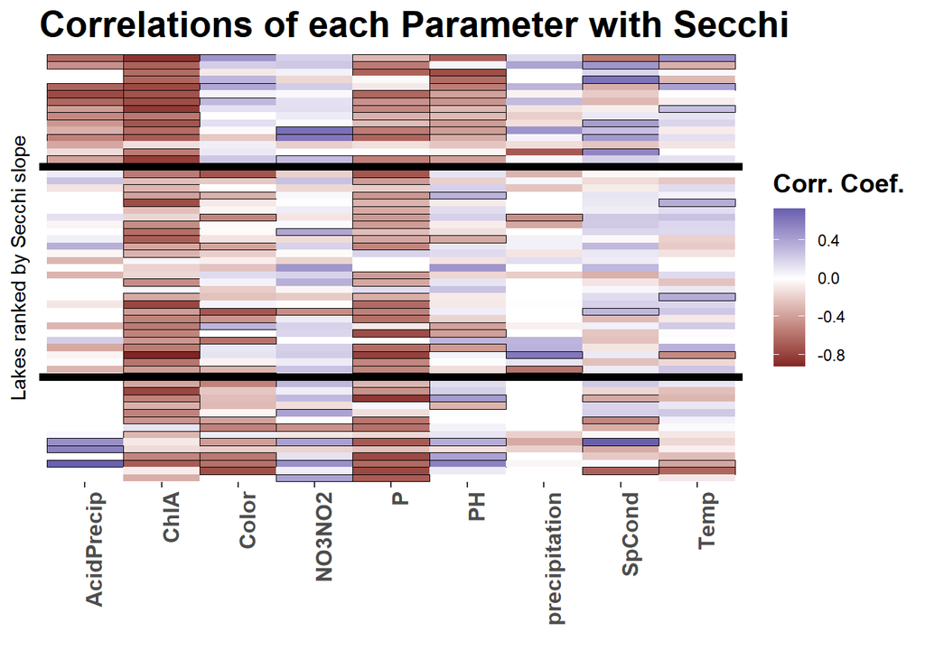

## Correlations SpCond

Correlations with parameters we measured

Correlations with parameters we didn’t measure

Table of correlation results. Black outlined boxes are statistically significant (p<0.05) and color indicates magnitude. Lakes below the black line have significant negative trends in SpCond

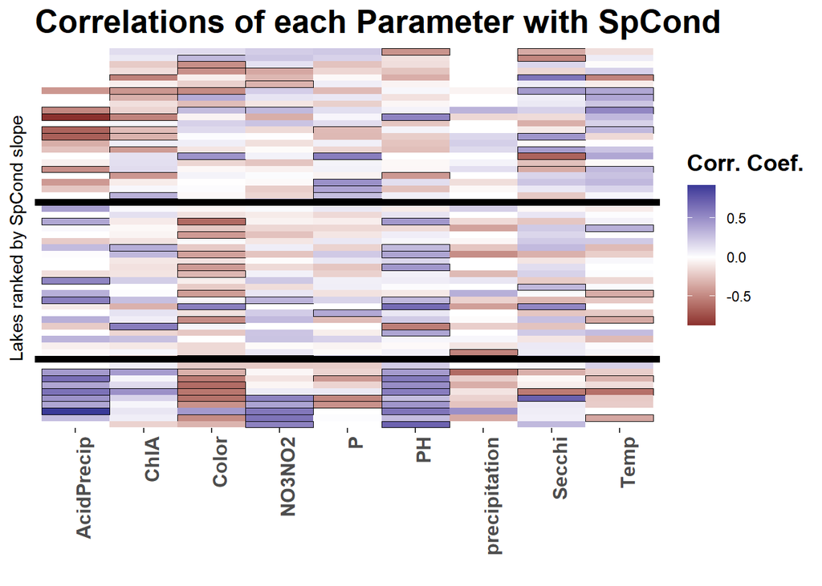

## Correlations Temp

Correlations with parameters we measured

Correlations with parameters we didn’t measure

Table of correlation results. Black outlined boxes are statistically significant (p<0.05) and color indicates magnitude. Lakes below the black line have significant negative trends in Temp

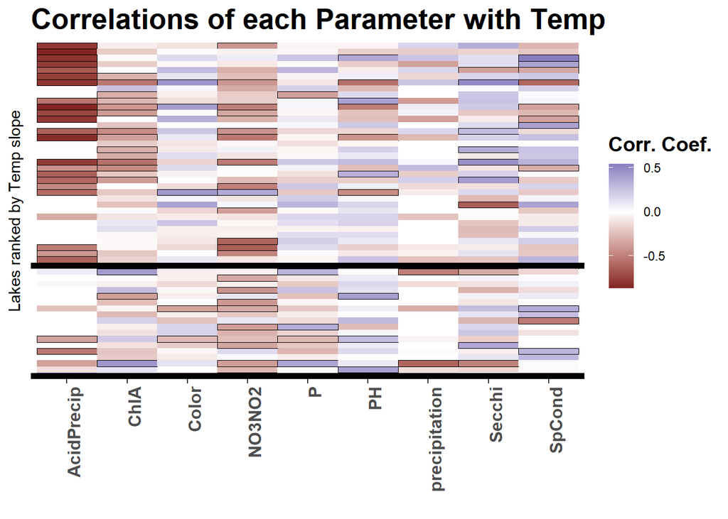